# Risk Factor Analysis

## Outcome Variable

**Outcome Variable:** y_rate_len

## Predictor Variables

**Intervention Variable:** exclfeed36

**Adjustment Set:**

unadjusted

## Stratifying Variables

The analysis was stratified on these variable(s):

- agecat
- studyid
- country

## Data Summary

| agecat | studyid | country | exclfeed36 | n_cell | n |
| --- | --- | --- | --- | --- | --- |
| 0-3 months | ki0047075b-MAL-ED | BANGLADESH | 1 | 32 | 242 |
| 0-3 months | ki0047075b-MAL-ED | BANGLADESH | 0 | 210 | 242 |
| 0-3 months | ki0047075b-MAL-ED | BRAZIL | 1 | 8 | 167 |
| 0-3 months | ki0047075b-MAL-ED | BRAZIL | 0 | 159 | 167 |
| 0-3 months | ki0047075b-MAL-ED | INDIA | 1 | 4 | 181 |
| 0-3 months | ki0047075b-MAL-ED | INDIA | 0 | 177 | 181 |
| 0-3 months | ki0047075b-MAL-ED | NEPAL | 1 | 4 | 154 |
| 0-3 months | ki0047075b-MAL-ED | NEPAL | 0 | 150 | 154 |
| 0-3 months | ki0047075b-MAL-ED | PERU | 1 | 5 | 263 |
| 0-3 months | ki0047075b-MAL-ED | PERU | 0 | 258 | 263 |
| 0-3 months | ki0047075b-MAL-ED | SOUTH AFRICA | 1 | 0 | 209 |
| 0-3 months | ki0047075b-MAL-ED | SOUTH AFRICA | 0 | 209 | 209 |
| 0-3 months | ki0047075b-MAL-ED | TANZANIA, UNITED REPUBLIC OF | 1 | 3 | 223 |
| 0-3 months | ki0047075b-MAL-ED | TANZANIA, UNITED REPUBLIC OF | 0 | 220 | 223 |
| 0-3 months | ki1000108-CMC-V-BCS-2002 | INDIA | 1 | 2 | 2 |
| 0-3 months | ki1000108-CMC-V-BCS-2002 | INDIA | 0 | 0 | 2 |
| 0-3 months | ki1000108-IRC | INDIA | 1 | 0 | 4 |
| 0-3 months | ki1000108-IRC | INDIA | 0 | 4 | 4 |
| 0-3 months | ki1000109-EE | PAKISTAN | 1 | 2 | 6 |
| 0-3 months | ki1000109-EE | PAKISTAN | 0 | 4 | 6 |
| 0-3 months | ki1017093b-PROVIDE | BANGLADESH | 1 | 161 | 634 |
| 0-3 months | ki1017093b-PROVIDE | BANGLADESH | 0 | 473 | 634 |
| 0-3 months | ki1101329-Keneba | GAMBIA | 1 | 326 | 1116 |
| 0-3 months | ki1101329-Keneba | GAMBIA | 0 | 790 | 1116 |
| 0-3 months | ki1113344-GMS-Nepal | NEPAL | 1 | 372 | 465 |
| 0-3 months | ki1113344-GMS-Nepal | NEPAL | 0 | 93 | 465 |
| 0-3 months | kiGH5241-JiVitA-3 | BANGLADESH | 1 | 3760 | 4812 |
| 0-3 months | kiGH5241-JiVitA-3 | BANGLADESH | 0 | 1052 | 4812 |
| 0-3 months | kiGH5241-JiVitA-4 | BANGLADESH | 1 | 493 | 581 |
| 0-3 months | kiGH5241-JiVitA-4 | BANGLADESH | 0 | 88 | 581 |

[output cut: 214 more lines]

The following strata were considered:

- agecat: 0-3 months, studyid: ki0047075b-MAL-ED, country: BANGLADESH
- agecat: 0-3 months, studyid: ki0047075b-MAL-ED, country: BRAZIL
- agecat: 0-3 months, studyid: ki0047075b-MAL-ED, country: INDIA
- agecat: 0-3 months, studyid: ki0047075b-MAL-ED, country: NEPAL
- agecat: 0-3 months, studyid: ki0047075b-MAL-ED, country: PERU
- agecat: 0-3 months, studyid: ki0047075b-MAL-ED, country: SOUTH AFRICA
- agecat: 0-3 months, studyid: ki0047075b-MAL-ED, country: TANZANIA, UNITED REPUBLIC OF
- agecat: 0-3 months, studyid: ki1000108-CMC-V-BCS-2002, country: INDIA
- agecat: 0-3 months, studyid: ki1000108-IRC, country: INDIA
- agecat: 0-3 months, studyid: ki1000109-EE, country: PAKISTAN
- agecat: 0-3 months, studyid: ki1017093b-PROVIDE, country: BANGLADESH
- agecat: 0-3 months, studyid: ki1101329-Keneba, country: GAMBIA
- agecat: 0-3 months, studyid: ki1113344-GMS-Nepal, country: NEPAL
- agecat: 0-3 months, studyid: kiGH5241-JiVitA-3, country: BANGLADESH
- agecat: 0-3 months, studyid: kiGH5241-JiVitA-4, country: BANGLADESH
- agecat: 12-15 months, studyid: ki0047075b-MAL-ED, country: BANGLADESH
- agecat: 12-15 months, studyid: ki0047075b-MAL-ED, country: BRAZIL
- agecat: 12-15 months, studyid: ki0047075b-MAL-ED, country: INDIA
- agecat: 12-15 months, studyid: ki0047075b-MAL-ED, country: NEPAL
- agecat: 12-15 months, studyid: ki0047075b-MAL-ED, country: PERU
- agecat: 12-15 months, studyid: ki0047075b-MAL-ED, country: SOUTH AFRICA
- agecat: 12-15 months, studyid: ki0047075b-MAL-ED, country: TANZANIA, UNITED REPUBLIC OF
- agecat: 12-15 months, studyid: ki1000108-CMC-V-BCS-2002, country: INDIA
- agecat: 12-15 months, studyid: ki1000108-IRC, country: INDIA
- agecat: 12-15 months, studyid: ki1000109-EE, country: PAKISTAN
- agecat: 12-15 months, studyid: ki1000304b-SAS-FoodSuppl, country: INDIA
- agecat: 12-15 months, studyid: ki1017093b-PROVIDE, country: BANGLADESH
- agecat: 12-15 months, studyid: ki1101329-Keneba, country: GAMBIA
- agecat: 12-15 months, studyid: ki1113344-GMS-Nepal, country: NEPAL
- agecat: 12-15 months, studyid: ki1148112-LCNI-5, country: MALAWI
- agecat: 12-15 months, studyid: kiGH5241-JiVitA-4, country: BANGLADESH
- agecat: 15-18 months, studyid: ki0047075b-MAL-ED, country: BANGLADESH
- agecat: 15-18 months, studyid: ki0047075b-MAL-ED, country: BRAZIL
- agecat: 15-18 months, studyid: ki0047075b-MAL-ED, country: INDIA
- agecat: 15-18 months, studyid: ki0047075b-MAL-ED, country: NEPAL
- agecat: 15-18 months, studyid: ki0047075b-MAL-ED, country: PERU
- agecat: 15-18 months, studyid: ki0047075b-MAL-ED, country: SOUTH AFRICA
- agecat: 15-18 months, studyid: ki0047075b-MAL-ED, country: TANZANIA, UNITED REPUBLIC OF
- agecat: 15-18 months, studyid: ki1000108-CMC-V-BCS-2002, country: INDIA
- agecat: 15-18 months, studyid: ki1000108-IRC, country: INDIA
- agecat: 15-18 months, studyid: ki1000109-EE, country: PAKISTAN
- agecat: 15-18 months, studyid: ki1000304b-SAS-FoodSuppl, country: INDIA
- agecat: 15-18 months, studyid: ki1017093b-PROVIDE, country: BANGLADESH
- agecat: 15-18 months, studyid: ki1101329-Keneba, country: GAMBIA
- agecat: 15-18 months, studyid: ki1113344-GMS-Nepal, country: NEPAL
- agecat: 15-18 months, studyid: ki1148112-LCNI-5, country: MALAWI
- agecat: 15-18 months, studyid: kiGH5241-JiVitA-4, country: BANGLADESH
- agecat: 18-21 months, studyid: ki0047075b-MAL-ED, country: BANGLADESH
- agecat: 18-21 months, studyid: ki0047075b-MAL-ED, country: BRAZIL
- agecat: 18-21 months, studyid: ki0047075b-MAL-ED, country: INDIA
- agecat: 18-21 months, studyid: ki0047075b-MAL-ED, country: NEPAL
- agecat: 18-21 months, studyid: ki0047075b-MAL-ED, country: PERU
- agecat: 18-21 months, studyid: ki0047075b-MAL-ED, country: SOUTH AFRICA
- agecat: 18-21 months, studyid: ki0047075b-MAL-ED, country: TANZANIA, UNITED REPUBLIC OF
- agecat: 18-21 months, studyid: ki1000108-CMC-V-BCS-2002, country: INDIA
- agecat: 18-21 months, studyid: ki1000108-IRC, country: INDIA
- agecat: 18-21 months, studyid: ki1000109-EE, country: PAKISTAN
- agecat: 18-21 months, studyid: ki1017093b-PROVIDE, country: BANGLADESH
- agecat: 18-21 months, studyid: ki1101329-Keneba, country: GAMBIA
- agecat: 18-21 months, studyid: ki1113344-GMS-Nepal, country: NEPAL
- agecat: 18-21 months, studyid: ki1148112-LCNI-5, country: MALAWI
- agecat: 21-24 months, studyid: ki0047075b-MAL-ED, country: BANGLADESH
- agecat: 21-24 months, studyid: ki0047075b-MAL-ED, country: BRAZIL
- agecat: 21-24 months, studyid: ki0047075b-MAL-ED, country: INDIA
- agecat: 21-24 months, studyid: ki0047075b-MAL-ED, country: NEPAL
- agecat: 21-24 months, studyid: ki0047075b-MAL-ED, country: PERU
- agecat: 21-24 months, studyid: ki0047075b-MAL-ED, country: SOUTH AFRICA
- agecat: 21-24 months, studyid: ki0047075b-MAL-ED, country: TANZANIA, UNITED REPUBLIC OF
- agecat: 21-24 months, studyid: ki1000108-CMC-V-BCS-2002, country: INDIA
- agecat: 21-24 months, studyid: ki1000108-IRC, country: INDIA
- agecat: 21-24 months, studyid: ki1000109-EE, country: PAKISTAN
- agecat: 21-24 months, studyid: ki1017093b-PROVIDE, country: BANGLADESH
- agecat: 21-24 months, studyid: ki1101329-Keneba, country: GAMBIA
- agecat: 21-24 months, studyid: ki1113344-GMS-Nepal, country: NEPAL
- agecat: 21-24 months, studyid: ki1148112-LCNI-5, country: MALAWI
- agecat: 3-6 months, studyid: ki0047075b-MAL-ED, country: BANGLADESH
- agecat: 3-6 months, studyid: ki0047075b-MAL-ED, country: BRAZIL
- agecat: 3-6 months, studyid: ki0047075b-MAL-ED, country: INDIA
- agecat: 3-6 months, studyid: ki0047075b-MAL-ED, country: NEPAL
- agecat: 3-6 months, studyid: ki0047075b-MAL-ED, country: PERU
- agecat: 3-6 months, studyid: ki0047075b-MAL-ED, country: SOUTH AFRICA
- agecat: 3-6 months, studyid: ki0047075b-MAL-ED, country: TANZANIA, UNITED REPUBLIC OF
- agecat: 3-6 months, studyid: ki1000108-CMC-V-BCS-2002, country: INDIA
- agecat: 3-6 months, studyid: ki1000108-IRC, country: INDIA
- agecat: 3-6 months, studyid: ki1000109-EE, country: PAKISTAN
- agecat: 3-6 months, studyid: ki1017093b-PROVIDE, country: BANGLADESH
- agecat: 3-6 months, studyid: ki1101329-Keneba, country: GAMBIA
- agecat: 3-6 months, studyid: ki1113344-GMS-Nepal, country: NEPAL
- agecat: 3-6 months, studyid: kiGH5241-JiVitA-3, country: BANGLADESH
- agecat: 3-6 months, studyid: kiGH5241-JiVitA-4, country: BANGLADESH
- agecat: 6-9 months, studyid: ki0047075b-MAL-ED, country: BANGLADESH
- agecat: 6-9 months, studyid: ki0047075b-MAL-ED, country: BRAZIL
- agecat: 6-9 months, studyid: ki0047075b-MAL-ED, country: INDIA
- agecat: 6-9 months, studyid: ki0047075b-MAL-ED, country: NEPAL
- agecat: 6-9 months, studyid: ki0047075b-MAL-ED, country: PERU
- agecat: 6-9 months, studyid: ki0047075b-MAL-ED, country: SOUTH AFRICA
- agecat: 6-9 months, studyid: ki0047075b-MAL-ED, country: TANZANIA, UNITED REPUBLIC OF
- agecat: 6-9 months, studyid: ki1000108-CMC-V-BCS-2002, country: INDIA
- agecat: 6-9 months, studyid: ki1000108-IRC, country: INDIA
- agecat: 6-9 months, studyid: ki1000109-EE, country: PAKISTAN
- agecat: 6-9 months, studyid: ki1000304b-SAS-FoodSuppl, country: INDIA
- agecat: 6-9 months, studyid: ki1017093b-PROVIDE, country: BANGLADESH
- agecat: 6-9 months, studyid: ki1101329-Keneba, country: GAMBIA
- agecat: 6-9 months, studyid: ki1113344-GMS-Nepal, country: NEPAL
- agecat: 6-9 months, studyid: ki1148112-LCNI-5, country: MALAWI
- agecat: 6-9 months, studyid: kiGH5241-JiVitA-4, country: BANGLADESH
- agecat: 9-12 months, studyid: ki0047075b-MAL-ED, country: BANGLADESH
- agecat: 9-12 months, studyid: ki0047075b-MAL-ED, country: BRAZIL
- agecat: 9-12 months, studyid: ki0047075b-MAL-ED, country: INDIA
- agecat: 9-12 months, studyid: ki0047075b-MAL-ED, country: NEPAL
- agecat: 9-12 months, studyid: ki0047075b-MAL-ED, country: PERU
- agecat: 9-12 months, studyid: ki0047075b-MAL-ED, country: SOUTH AFRICA
- agecat: 9-12 months, studyid: ki0047075b-MAL-ED, country: TANZANIA, UNITED REPUBLIC OF
- agecat: 9-12 months, studyid: ki1000108-CMC-V-BCS-2002, country: INDIA
- agecat: 9-12 months, studyid: ki1000108-IRC, country: INDIA
- agecat: 9-12 months, studyid: ki1000109-EE, country: PAKISTAN
- agecat: 9-12 months, studyid: ki1000304b-SAS-FoodSuppl, country: INDIA
- agecat: 9-12 months, studyid: ki1017093b-PROVIDE, country: BANGLADESH
- agecat: 9-12 months, studyid: ki1101329-Keneba, country: GAMBIA
- agecat: 9-12 months, studyid: ki1113344-GMS-Nepal, country: NEPAL
- agecat: 9-12 months, studyid: ki1148112-LCNI-5, country: MALAWI
- agecat: 9-12 months, studyid: kiGH5241-JiVitA-4, country: BANGLADESH

### Dropped Strata

Some strata were dropped due to rare outcomes:

- agecat: 0-3 months, studyid: ki0047075b-MAL-ED, country: INDIA
- agecat: 0-3 months, studyid: ki0047075b-MAL-ED, country: NEPAL
- agecat: 0-3 months, studyid: ki0047075b-MAL-ED, country: SOUTH AFRICA
- agecat: 0-3 months, studyid: ki0047075b-MAL-ED, country: TANZANIA, UNITED REPUBLIC OF
- agecat: 0-3 months, studyid: ki1000108-CMC-V-BCS-2002, country: INDIA
- agecat: 0-3 months, studyid: ki1000108-IRC, country: INDIA
- agecat: 0-3 months, studyid: ki1000109-EE, country: PAKISTAN
- agecat: 3-6 months, studyid: ki0047075b-MAL-ED, country: NEPAL
- agecat: 3-6 months, studyid: ki0047075b-MAL-ED, country: SOUTH AFRICA
- agecat: 3-6 months, studyid: ki0047075b-MAL-ED, country: TANZANIA, UNITED REPUBLIC OF
- agecat: 3-6 months, studyid: ki1000108-CMC-V-BCS-2002, country: INDIA
- agecat: 3-6 months, studyid: ki1000108-IRC, country: INDIA
- agecat: 3-6 months, studyid: ki1000109-EE, country: PAKISTAN
- agecat: 6-9 months, studyid: ki0047075b-MAL-ED, country: NEPAL
- agecat: 6-9 months, studyid: ki0047075b-MAL-ED, country: SOUTH AFRICA
- agecat: 6-9 months, studyid: ki0047075b-MAL-ED, country: TANZANIA, UNITED REPUBLIC OF
- agecat: 6-9 months, studyid: ki1000108-CMC-V-BCS-2002, country: INDIA
- agecat: 6-9 months, studyid: ki1000108-IRC, country: INDIA
- agecat: 6-9 months, studyid: ki1000109-EE, country: PAKISTAN
- agecat: 6-9 months, studyid: ki1000304b-SAS-FoodSuppl, country: INDIA
- agecat: 9-12 months, studyid: ki0047075b-MAL-ED, country: NEPAL
- agecat: 9-12 months, studyid: ki0047075b-MAL-ED, country: SOUTH AFRICA
- agecat: 9-12 months, studyid: ki0047075b-MAL-ED, country: TANZANIA, UNITED REPUBLIC OF
- agecat: 9-12 months, studyid: ki1000108-CMC-V-BCS-2002, country: INDIA
- agecat: 9-12 months, studyid: ki1000108-IRC, country: INDIA
- agecat: 9-12 months, studyid: ki1000109-EE, country: PAKISTAN
- agecat: 9-12 months, studyid: ki1000304b-SAS-FoodSuppl, country: INDIA
- agecat: 12-15 months, studyid: ki0047075b-MAL-ED, country: NEPAL
- agecat: 12-15 months, studyid: ki0047075b-MAL-ED, country: SOUTH AFRICA
- agecat: 12-15 months, studyid: ki0047075b-MAL-ED, country: TANZANIA, UNITED REPUBLIC OF
- agecat: 12-15 months, studyid: ki1000108-CMC-V-BCS-2002, country: INDIA
- agecat: 12-15 months, studyid: ki1000108-IRC, country: INDIA
- agecat: 12-15 months, studyid: ki1000109-EE, country: PAKISTAN
- agecat: 12-15 months, studyid: ki1000304b-SAS-FoodSuppl, country: INDIA
- agecat: 12-15 months, studyid: ki1148112-LCNI-5, country: MALAWI
- agecat: 15-18 months, studyid: ki0047075b-MAL-ED, country: NEPAL
- agecat: 15-18 months, studyid: ki0047075b-MAL-ED, country: SOUTH AFRICA
- agecat: 15-18 months, studyid: ki0047075b-MAL-ED, country: TANZANIA, UNITED REPUBLIC OF
- agecat: 15-18 months, studyid: ki1000108-CMC-V-BCS-2002, country: INDIA
- agecat: 15-18 months, studyid: ki1000108-IRC, country: INDIA
- agecat: 15-18 months, studyid: ki1000109-EE, country: PAKISTAN
- agecat: 15-18 months, studyid: ki1000304b-SAS-FoodSuppl, country: INDIA
- agecat: 15-18 months, studyid: ki1148112-LCNI-5, country: MALAWI
- agecat: 18-21 months, studyid: ki0047075b-MAL-ED, country: NEPAL
- agecat: 18-21 months, studyid: ki0047075b-MAL-ED, country: PERU
- agecat: 18-21 months, studyid: ki0047075b-MAL-ED, country: SOUTH AFRICA
- agecat: 18-21 months, studyid: ki0047075b-MAL-ED, country: TANZANIA, UNITED REPUBLIC OF
- agecat: 18-21 months, studyid: ki1000108-CMC-V-BCS-2002, country: INDIA
- agecat: 18-21 months, studyid: ki1000108-IRC, country: INDIA
- agecat: 18-21 months, studyid: ki1000109-EE, country: PAKISTAN
- agecat: 21-24 months, studyid: ki0047075b-MAL-ED, country: NEPAL
- agecat: 21-24 months, studyid: ki0047075b-MAL-ED, country: PERU
- agecat: 21-24 months, studyid: ki0047075b-MAL-ED, country: SOUTH AFRICA
- agecat: 21-24 months, studyid: ki0047075b-MAL-ED, country: TANZANIA, UNITED REPUBLIC OF
- agecat: 21-24 months, studyid: ki1000108-CMC-V-BCS-2002, country: INDIA
- agecat: 21-24 months, studyid: ki1000108-IRC, country: INDIA
- agecat: 21-24 months, studyid: ki1000109-EE, country: PAKISTAN

## Methods Detail

We’re interested in the causal parameters $E[Y_a]$ for all values of $a \in \mathcal{A}$. These parameters represent the mean outcome if, possibly contrary to fact, we intervened to set all units to have $A=a$. Under the randomization and positivity assumptions, these are identified by the statistical parameters $\psi_a=E_W[E_{Y|A,W}(Y|A=a,W)]$. In addition, we’re interested in the mean of $Y$, $E[Y]$ under no intervention (the observed mean). We will estimate these parameters by using SuperLearner to fit the relevant likelihood factors – $E_{Y|A,W}(Y|A=a,W)$ and $p(A=a|W)$, and then updating our likelihood fit using a joint TMLE.

For unadjusted analyses ($W=\{\}$), initial likelihoods were estimated using Lrnr_glm to estimate the simple $E(Y|A)$ and Lrnr_mean to estimate $p(A)$. For adjusted analyses, a small library containing Lrnr_glmnet, Lrnr_xgboost, and Lrnr_mean was used.

Having estimated these parameters, we will then use the delta method to estimate relative risks and attributable risks relative to a prespecified baseline level of $A$.

# Results Detail

## Results Plots

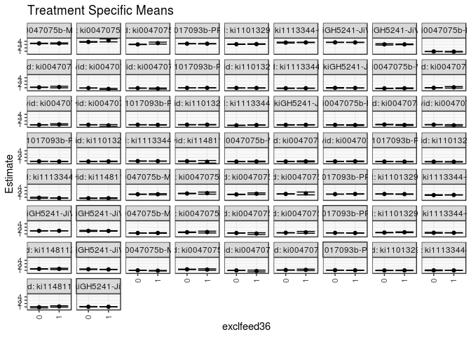

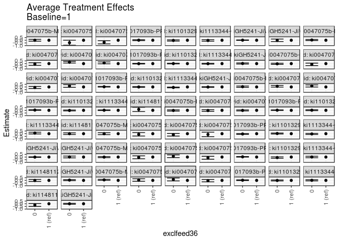

[figure not shown]

## Results Table

### Parameter: TSM

| agecat | studyid | country | intervention_level | baseline_level | estimate | ci_lower | ci_upper |
| --- | --- | --- | --- | --- | --- | --- | --- |
| 0-3 months | ki0047075b-MAL-ED | BANGLADESH | 1 | NA | 3.3402762 | 3.1845940 | 3.4959583 |
| 0-3 months | ki0047075b-MAL-ED | BANGLADESH | 0 | NA | 3.3402081 | 3.2680749 | 3.4123413 |
| 0-3 months | ki0047075b-MAL-ED | BRAZIL | 1 | NA | 4.2459722 | 3.7916926 | 4.7002519 |
| 0-3 months | ki0047075b-MAL-ED | BRAZIL | 0 | NA | 3.7865574 | 3.6750596 | 3.8980552 |
| 0-3 months | ki0047075b-MAL-ED | PERU | 1 | NA | 3.4234571 | 3.1291622 | 3.7177520 |
| 0-3 months | ki0047075b-MAL-ED | PERU | 0 | NA | 3.0417843 | 2.9741800 | 3.1093886 |
| 0-3 months | ki1017093b-PROVIDE | BANGLADESH | 1 | NA | 3.2473402 | 3.1820286 | 3.3126519 |
| 0-3 months | ki1017093b-PROVIDE | BANGLADESH | 0 | NA | 3.2601215 | 3.2159568 | 3.3042863 |
| 0-3 months | ki1101329-Keneba | GAMBIA | 1 | NA | 3.1364740 | 3.0449330 | 3.2280149 |
| 0-3 months | ki1101329-Keneba | GAMBIA | 0 | NA | 3.1015418 | 3.0402940 | 3.1627895 |
| 0-3 months | ki1113344-GMS-Nepal | NEPAL | 1 | NA | 3.6253644 | 3.5675080 | 3.6832209 |
| 0-3 months | ki1113344-GMS-Nepal | NEPAL | 0 | NA | 3.5854484 | 3.4559271 | 3.7149698 |
| 0-3 months | kiGH5241-JiVitA-3 | BANGLADESH | 1 | NA | 3.6321873 | 3.6121463 | 3.6522283 |
| 0-3 months | kiGH5241-JiVitA-3 | BANGLADESH | 0 | NA | 3.6506568 | 3.6103295 | 3.6909840 |
| 0-3 months | kiGH5241-JiVitA-4 | BANGLADESH | 1 | NA | 3.0572806 | 2.9482997 | 3.1662615 |
| 0-3 months | kiGH5241-JiVitA-4 | BANGLADESH | 0 | NA | 3.0549662 | 2.8510202 | 3.2589121 |
| 3-6 months | ki0047075b-MAL-ED | BANGLADESH | 1 | NA | 1.9329001 | 1.7541150 | 2.1116852 |
| 3-6 months | ki0047075b-MAL-ED | BANGLADESH | 0 | NA | 1.9250838 | 1.8737516 | 1.9764159 |
| 3-6 months | ki0047075b-MAL-ED | BRAZIL | 1 | NA | 2.2510346 | 1.9355488 | 2.5665204 |
| 3-6 months | ki0047075b-MAL-ED | BRAZIL | 0 | NA | 2.1396558 | 2.0579278 | 2.2213839 |
| 3-6 months | ki0047075b-MAL-ED | INDIA | 1 | NA | 2.0750209 | 1.8360347 | 2.3140071 |
| 3-6 months | ki0047075b-MAL-ED | INDIA | 0 | NA | 1.8770379 | 1.8121355 | 1.9419403 |
| 3-6 months | ki0047075b-MAL-ED | PERU | 1 | NA | 2.1589526 | 1.7407037 | 2.5772015 |
| 3-6 months | ki0047075b-MAL-ED | PERU | 0 | NA | 2.0123885 | 1.9453808 | 2.0793963 |
| 3-6 months | ki1017093b-PROVIDE | BANGLADESH | 1 | NA | 2.0077702 | 1.9424627 | 2.0730776 |
| 3-6 months | ki1017093b-PROVIDE | BANGLADESH | 0 | NA | 1.9554988 | 1.9164052 | 1.9945925 |
| 3-6 months | ki1101329-Keneba | GAMBIA | 1 | NA | 1.9676653 | 1.8912882 | 2.0440424 |
| 3-6 months | ki1101329-Keneba | GAMBIA | 0 | NA | 2.0004527 | 1.9507829 | 2.0501225 |
| 3-6 months | ki1113344-GMS-Nepal | NEPAL | 1 | NA | 1.7180444 | 1.6744326 | 1.7616562 |
| 3-6 months | ki1113344-GMS-Nepal | NEPAL | 0 | NA | 1.6716342 | 1.5771432 | 1.7661253 |

[output cut: 100 more lines]

### Parameter: E(Y)

| agecat | studyid | country | intervention_level | baseline_level | estimate | ci_lower | ci_upper |
| --- | --- | --- | --- | --- | --- | --- | --- |
| 0-3 months | ki0047075b-MAL-ED | BANGLADESH | NA | NA | 3.3402171 | 3.2743239 | 3.4061103 |
| 0-3 months | ki0047075b-MAL-ED | BRAZIL | NA | NA | 3.8085653 | 3.6991781 | 3.9179525 |
| 0-3 months | ki0047075b-MAL-ED | PERU | NA | NA | 3.0490404 | 2.9824173 | 3.1156636 |
| 0-3 months | ki1017093b-PROVIDE | BANGLADESH | NA | NA | 3.2568758 | 3.2199850 | 3.2937666 |
| 0-3 months | ki1101329-Keneba | GAMBIA | NA | NA | 3.1117460 | 3.0607980 | 3.1626940 |
| 0-3 months | ki1113344-GMS-Nepal | NEPAL | NA | NA | 3.6173812 | 3.5643204 | 3.6704421 |
| 0-3 months | kiGH5241-JiVitA-3 | BANGLADESH | NA | NA | 3.6362251 | 3.6173143 | 3.6551359 |
| 0-3 months | kiGH5241-JiVitA-4 | BANGLADESH | NA | NA | 3.0569301 | 2.9604441 | 3.1534160 |
| 3-6 months | ki0047075b-MAL-ED | BANGLADESH | NA | NA | 1.9261033 | 1.8757410 | 1.9764655 |
| 3-6 months | ki0047075b-MAL-ED | BRAZIL | NA | NA | 2.1460815 | 2.0668679 | 2.2252951 |
| 3-6 months | ki0047075b-MAL-ED | INDIA | NA | NA | 1.8848530 | 1.8216037 | 1.9481024 |
| 3-6 months | ki0047075b-MAL-ED | PERU | NA | NA | 2.0156821 | 1.9494666 | 2.0818976 |
| 3-6 months | ki1017093b-PROVIDE | BANGLADESH | NA | NA | 1.9680194 | 1.9343778 | 2.0016611 |
| 3-6 months | ki1101329-Keneba | GAMBIA | NA | NA | 1.9917249 | 1.9499823 | 2.0334676 |
| 3-6 months | ki1113344-GMS-Nepal | NEPAL | NA | NA | 1.7085606 | 1.6688133 | 1.7483079 |
| 3-6 months | kiGH5241-JiVitA-3 | BANGLADESH | NA | NA | 1.9090492 | 1.8895126 | 1.9285858 |
| 3-6 months | kiGH5241-JiVitA-4 | BANGLADESH | NA | NA | 1.8762089 | 1.8108032 | 1.9416146 |
| 6-9 months | ki0047075b-MAL-ED | BANGLADESH | NA | NA | 1.2480451 | 1.2083209 | 1.2877694 |
| 6-9 months | ki0047075b-MAL-ED | BRAZIL | NA | NA | 1.4831159 | 1.4026580 | 1.5635738 |
| 6-9 months | ki0047075b-MAL-ED | INDIA | NA | NA | 1.2403346 | 1.1889010 | 1.2917682 |
| 6-9 months | ki0047075b-MAL-ED | PERU | NA | NA | 1.3199965 | 1.2656612 | 1.3743319 |
| 6-9 months | ki1017093b-PROVIDE | BANGLADESH | NA | NA | 1.2824185 | 1.2571827 | 1.3076542 |
| 6-9 months | ki1101329-Keneba | GAMBIA | NA | NA | 1.4086727 | 1.3529368 | 1.4644086 |
| 6-9 months | ki1113344-GMS-Nepal | NEPAL | NA | NA | 1.3144775 | 1.2731267 | 1.3558284 |
| 6-9 months | ki1148112-LCNI-5 | MALAWI | NA | NA | 1.4372604 | 1.3755150 | 1.4990057 |
| 6-9 months | kiGH5241-JiVitA-4 | BANGLADESH | NA | NA | 1.2932006 | 1.2545240 | 1.3318772 |
| 9-12 months | ki0047075b-MAL-ED | BANGLADESH | NA | NA | 0.9896446 | 0.9509752 | 1.0283140 |
| 9-12 months | ki0047075b-MAL-ED | BRAZIL | NA | NA | 1.2982559 | 1.2240694 | 1.3724425 |
| 9-12 months | ki0047075b-MAL-ED | INDIA | NA | NA | 0.9798686 | 0.9411954 | 1.0185419 |
| 9-12 months | ki0047075b-MAL-ED | PERU | NA | NA | 1.0985124 | 1.0475959 | 1.1494289 |
| 9-12 months | ki1017093b-PROVIDE | BANGLADESH | NA | NA | 1.0503544 | 1.0233548 | 1.0773539 |
| 9-12 months | ki1101329-Keneba | GAMBIA | NA | NA | 0.9859004 | 0.9415938 | 1.0302070 |
| 9-12 months | ki1113344-GMS-Nepal | NEPAL | NA | NA | 0.9984152 | 0.9640726 | 1.0327578 |
| 9-12 months | ki1148112-LCNI-5 | MALAWI | NA | NA | 0.9706344 | 0.8246089 | 1.1166600 |
| 9-12 months | kiGH5241-JiVitA-4 | BANGLADESH | NA | NA | 1.0477402 | 1.0112922 | 1.0841882 |
| 12-15 months | ki0047075b-MAL-ED | BANGLADESH | NA | NA | 0.9141004 | 0.8737459 | 0.9544550 |
| 12-15 months | ki0047075b-MAL-ED | BRAZIL | NA | NA | 1.1421774 | 1.0831447 | 1.2012100 |
| 12-15 months | ki0047075b-MAL-ED | INDIA | NA | NA | 0.9075845 | 0.8681682 | 0.9470009 |
| 12-15 months | ki0047075b-MAL-ED | PERU | NA | NA | 0.8917280 | 0.8454370 | 0.9380189 |
| 12-15 months | ki1017093b-PROVIDE | BANGLADESH | NA | NA | 0.9598579 | 0.9336493 | 0.9860665 |
| 12-15 months | ki1101329-Keneba | GAMBIA | NA | NA | 0.9411780 | 0.9094953 | 0.9728606 |
| 12-15 months | ki1113344-GMS-Nepal | NEPAL | NA | NA | 0.8702474 | 0.8441404 | 0.8963544 |
| 12-15 months | kiGH5241-JiVitA-4 | BANGLADESH | NA | NA | 0.9412197 | 0.9046045 | 0.9778349 |
| 15-18 months | ki0047075b-MAL-ED | BANGLADESH | NA | NA | 0.8241226 | 0.7871907 | 0.8610544 |
| 15-18 months | ki0047075b-MAL-ED | BRAZIL | NA | NA | 1.0021114 | 0.9429996 | 1.0612232 |
| 15-18 months | ki0047075b-MAL-ED | INDIA | NA | NA | 0.8476806 | 0.8113849 | 0.8839763 |
| 15-18 months | ki0047075b-MAL-ED | PERU | NA | NA | 0.8534307 | 0.8111406 | 0.8957208 |
| 15-18 months | ki1017093b-PROVIDE | BANGLADESH | NA | NA | 0.8562969 | 0.8321689 | 0.8804249 |
| 15-18 months | ki1101329-Keneba | GAMBIA | NA | NA | 0.8768325 | 0.8429175 | 0.9107475 |
| 15-18 months | ki1113344-GMS-Nepal | NEPAL | NA | NA | 0.7596809 | 0.7265174 | 0.7928444 |
| 15-18 months | kiGH5241-JiVitA-4 | BANGLADESH | NA | NA | 0.8355464 | 0.7999363 | 0.8711564 |
| 18-21 months | ki0047075b-MAL-ED | BANGLADESH | NA | NA | 0.8133847 | 0.7790076 | 0.8477619 |
| 18-21 months | ki0047075b-MAL-ED | BRAZIL | NA | NA | 0.9160758 | 0.8452655 | 0.9868862 |
| 18-21 months | ki0047075b-MAL-ED | INDIA | NA | NA | 0.8759623 | 0.8406388 | 0.9112858 |
| 18-21 months | ki1017093b-PROVIDE | BANGLADESH | NA | NA | 0.8393900 | 0.8153565 | 0.8634234 |
| 18-21 months | ki1101329-Keneba | GAMBIA | NA | NA | 0.8164462 | 0.7785749 | 0.8543176 |
| 18-21 months | ki1113344-GMS-Nepal | NEPAL | NA | NA | 0.9045343 | 0.8683581 | 0.9407104 |
| 18-21 months | ki1148112-LCNI-5 | MALAWI | NA | NA | 0.8419773 | 0.7481346 | 0.9358201 |
| 21-24 months | ki0047075b-MAL-ED | BANGLADESH | NA | NA | 0.7694183 | 0.7339448 | 0.8048918 |
| 21-24 months | ki0047075b-MAL-ED | BRAZIL | NA | NA | 0.7961519 | 0.7521041 | 0.8401997 |
| 21-24 months | ki0047075b-MAL-ED | INDIA | NA | NA | 0.8269217 | 0.7961503 | 0.8576932 |
| 21-24 months | ki1017093b-PROVIDE | BANGLADESH | NA | NA | 0.7635979 | 0.7381659 | 0.7890298 |
| 21-24 months | ki1101329-Keneba | GAMBIA | NA | NA | 0.7224865 | 0.6857861 | 0.7591869 |
| 21-24 months | ki1113344-GMS-Nepal | NEPAL | NA | NA | 0.7920360 | 0.7445193 | 0.8395527 |
| 21-24 months | ki1148112-LCNI-5 | MALAWI | NA | NA | 0.7342569 | 0.6662316 | 0.8022822 |

### Parameter: ATE

| agecat | studyid | country | intervention_level | baseline_level | estimate | ci_lower | ci_upper |
| --- | --- | --- | --- | --- | --- | --- | --- |
| 0-3 months | ki0047075b-MAL-ED | BANGLADESH | 1 | 1 | 0.0000000 | 0.0000000 | 0.0000000 |
| 0-3 months | ki0047075b-MAL-ED | BANGLADESH | 0 | 1 | -0.0000681 | -0.1716493 | 0.1715132 |
| 0-3 months | ki0047075b-MAL-ED | BRAZIL | 1 | 1 | 0.0000000 | 0.0000000 | 0.0000000 |
| 0-3 months | ki0047075b-MAL-ED | BRAZIL | 0 | 1 | -0.4594149 | -0.9271773 | 0.0083476 |
| 0-3 months | ki0047075b-MAL-ED | PERU | 1 | 1 | 0.0000000 | 0.0000000 | 0.0000000 |
| 0-3 months | ki0047075b-MAL-ED | PERU | 0 | 1 | -0.3816728 | -0.6836328 | -0.0797128 |
| 0-3 months | ki1017093b-PROVIDE | BANGLADESH | 1 | 1 | 0.0000000 | 0.0000000 | 0.0000000 |
| 0-3 months | ki1017093b-PROVIDE | BANGLADESH | 0 | 1 | 0.0127813 | -0.0660612 | 0.0916238 |
| 0-3 months | ki1101329-Keneba | GAMBIA | 1 | 1 | 0.0000000 | 0.0000000 | 0.0000000 |
| 0-3 months | ki1101329-Keneba | GAMBIA | 0 | 1 | -0.0349322 | -0.1450732 | 0.0752088 |
| 0-3 months | ki1113344-GMS-Nepal | NEPAL | 1 | 1 | 0.0000000 | 0.0000000 | 0.0000000 |
| 0-3 months | ki1113344-GMS-Nepal | NEPAL | 0 | 1 | -0.0399160 | -0.1817721 | 0.1019400 |
| 0-3 months | kiGH5241-JiVitA-3 | BANGLADESH | 1 | 1 | 0.0000000 | 0.0000000 | 0.0000000 |
| 0-3 months | kiGH5241-JiVitA-3 | BANGLADESH | 0 | 1 | 0.0184695 | -0.0242130 | 0.0611519 |
| 0-3 months | kiGH5241-JiVitA-4 | BANGLADESH | 1 | 1 | 0.0000000 | 0.0000000 | 0.0000000 |
| 0-3 months | kiGH5241-JiVitA-4 | BANGLADESH | 0 | 1 | -0.0023144 | -0.2368312 | 0.2322024 |
| 3-6 months | ki0047075b-MAL-ED | BANGLADESH | 1 | 1 | 0.0000000 | 0.0000000 | 0.0000000 |
| 3-6 months | ki0047075b-MAL-ED | BANGLADESH | 0 | 1 | -0.0078163 | -0.1938246 | 0.1781920 |
| 3-6 months | ki0047075b-MAL-ED | BRAZIL | 1 | 1 | 0.0000000 | 0.0000000 | 0.0000000 |
| 3-6 months | ki0047075b-MAL-ED | BRAZIL | 0 | 1 | -0.1113788 | -0.4372787 | 0.2145212 |
| 3-6 months | ki0047075b-MAL-ED | INDIA | 1 | 1 | 0.0000000 | 0.0000000 | 0.0000000 |
| 3-6 months | ki0047075b-MAL-ED | INDIA | 0 | 1 | -0.1979830 | -0.4456254 | 0.0496593 |
| 3-6 months | ki0047075b-MAL-ED | PERU | 1 | 1 | 0.0000000 | 0.0000000 | 0.0000000 |
| 3-6 months | ki0047075b-MAL-ED | PERU | 0 | 1 | -0.1465641 | -0.5701466 | 0.2770185 |
| 3-6 months | ki1017093b-PROVIDE | BANGLADESH | 1 | 1 | 0.0000000 | 0.0000000 | 0.0000000 |
| 3-6 months | ki1017093b-PROVIDE | BANGLADESH | 0 | 1 | -0.0522713 | -0.1283856 | 0.0238429 |
| 3-6 months | ki1101329-Keneba | GAMBIA | 1 | 1 | 0.0000000 | 0.0000000 | 0.0000000 |
| 3-6 months | ki1101329-Keneba | GAMBIA | 0 | 1 | 0.0327874 | -0.0583200 | 0.1238948 |
| 3-6 months | ki1113344-GMS-Nepal | NEPAL | 1 | 1 | 0.0000000 | 0.0000000 | 0.0000000 |
| 3-6 months | ki1113344-GMS-Nepal | NEPAL | 0 | 1 | -0.0464102 | -0.1504800 | 0.0576597 |

[output cut: 100 more lines]

### Parameter: PAR

| agecat | studyid | country | intervention_level | baseline_level | estimate | ci_lower | ci_upper |
| --- | --- | --- | --- | --- | --- | --- | --- |
| 0-3 months | ki0047075b-MAL-ED | BANGLADESH | 1 | NA | -0.0000591 | -0.1489519 | 0.1488338 |
| 0-3 months | ki0047075b-MAL-ED | BRAZIL | 1 | NA | -0.4374070 | -0.8830117 | 0.0081977 |
| 0-3 months | ki0047075b-MAL-ED | PERU | 1 | NA | -0.3744167 | -0.6688953 | -0.0799380 |
| 0-3 months | ki1017093b-PROVIDE | BANGLADESH | 1 | NA | 0.0095356 | -0.0492870 | 0.0683581 |
| 0-3 months | ki1101329-Keneba | GAMBIA | 1 | NA | -0.0247280 | -0.1027007 | 0.0532447 |
| 0-3 months | ki1113344-GMS-Nepal | NEPAL | 1 | NA | -0.0079832 | -0.0363916 | 0.0204252 |
| 0-3 months | kiGH5241-JiVitA-3 | BANGLADESH | 1 | NA | 0.0040378 | -0.0052483 | 0.0133239 |
| 0-3 months | kiGH5241-JiVitA-4 | BANGLADESH | 1 | NA | -0.0003506 | -0.0358540 | 0.0351529 |
| 3-6 months | ki0047075b-MAL-ED | BANGLADESH | 1 | NA | -0.0067968 | -0.1685435 | 0.1549499 |
| 3-6 months | ki0047075b-MAL-ED | BRAZIL | 1 | NA | -0.1049531 | -0.4120715 | 0.2021653 |
| 3-6 months | ki0047075b-MAL-ED | INDIA | 1 | NA | -0.1901679 | -0.4280878 | 0.0477520 |
| 3-6 months | ki0047075b-MAL-ED | PERU | 1 | NA | -0.1432705 | -0.5562717 | 0.2697308 |
| 3-6 months | ki1017093b-PROVIDE | BANGLADESH | 1 | NA | -0.0397507 | -0.0976610 | 0.0181595 |
| 3-6 months | ki1101329-Keneba | GAMBIA | 1 | NA | 0.0240596 | -0.0428004 | 0.0909197 |
| 3-6 months | ki1113344-GMS-Nepal | NEPAL | 1 | NA | -0.0094838 | -0.0308191 | 0.0118514 |
| 3-6 months | kiGH5241-JiVitA-3 | BANGLADESH | 1 | NA | -0.0024054 | -0.0130981 | 0.0082873 |
| 3-6 months | kiGH5241-JiVitA-4 | BANGLADESH | 1 | NA | 0.0019667 | -0.0230333 | 0.0269666 |
| 6-9 months | ki0047075b-MAL-ED | BANGLADESH | 1 | NA | -0.0091968 | -0.0965405 | 0.0781468 |
| 6-9 months | ki0047075b-MAL-ED | BRAZIL | 1 | NA | -0.0476778 | -0.3047637 | 0.2094081 |
| 6-9 months | ki0047075b-MAL-ED | INDIA | 1 | NA | 0.1434039 | -0.1026096 | 0.3894174 |
| 6-9 months | ki0047075b-MAL-ED | PERU | 1 | NA | -0.1304608 | -0.3990978 | 0.1381761 |
| 6-9 months | ki1017093b-PROVIDE | BANGLADESH | 1 | NA | 0.0303701 | -0.0153263 | 0.0760665 |
| 6-9 months | ki1101329-Keneba | GAMBIA | 1 | NA | -0.0702036 | -0.1635825 | 0.0231753 |
| 6-9 months | ki1113344-GMS-Nepal | NEPAL | 1 | NA | 0.0014431 | -0.0258796 | 0.0287659 |
| 6-9 months | ki1148112-LCNI-5 | MALAWI | 1 | NA | -0.0131694 | -0.1720321 | 0.1456932 |
| 6-9 months | kiGH5241-JiVitA-4 | BANGLADESH | 1 | NA | 0.0112085 | -0.0088909 | 0.0313079 |
| 9-12 months | ki0047075b-MAL-ED | BANGLADESH | 1 | NA | 0.0830253 | -0.0063538 | 0.1724043 |
| 9-12 months | ki0047075b-MAL-ED | BRAZIL | 1 | NA | 0.0647066 | -0.1569811 | 0.2863943 |
| 9-12 months | ki0047075b-MAL-ED | INDIA | 1 | NA | 0.1695631 | -0.0960756 | 0.4352019 |
| 9-12 months | ki0047075b-MAL-ED | PERU | 1 | NA | -0.0506153 | -0.2653605 | 0.1641298 |
| 9-12 months | ki1017093b-PROVIDE | BANGLADESH | 1 | NA | 0.0261148 | -0.0224903 | 0.0747199 |
| 9-12 months | ki1101329-Keneba | GAMBIA | 1 | NA | -0.0083374 | -0.0731801 | 0.0565053 |
| 9-12 months | ki1113344-GMS-Nepal | NEPAL | 1 | NA | 0.0029443 | -0.0185331 | 0.0244216 |
| 9-12 months | ki1148112-LCNI-5 | MALAWI | 1 | NA | -0.1576408 | -0.3440762 | 0.0287946 |
| 9-12 months | kiGH5241-JiVitA-4 | BANGLADESH | 1 | NA | -0.0005591 | -0.0184094 | 0.0172913 |
| 12-15 months | ki0047075b-MAL-ED | BANGLADESH | 1 | NA | 0.0429492 | -0.0458640 | 0.1317624 |
| 12-15 months | ki0047075b-MAL-ED | BRAZIL | 1 | NA | -0.0730504 | -0.3061464 | 0.1600456 |
| 12-15 months | ki0047075b-MAL-ED | INDIA | 1 | NA | 0.2523161 | 0.1073622 | 0.3972700 |
| 12-15 months | ki0047075b-MAL-ED | PERU | 1 | NA | 0.1336334 | -0.0373524 | 0.3046192 |
| 12-15 months | ki1017093b-PROVIDE | BANGLADESH | 1 | NA | -0.0109257 | -0.0529984 | 0.0311470 |
| 12-15 months | ki1101329-Keneba | GAMBIA | 1 | NA | 0.0045446 | -0.0394117 | 0.0485009 |
| 12-15 months | ki1113344-GMS-Nepal | NEPAL | 1 | NA | -0.0027055 | -0.0169047 | 0.0114937 |
| 12-15 months | kiGH5241-JiVitA-4 | BANGLADESH | 1 | NA | 0.0046080 | -0.0165589 | 0.0257748 |
| 15-18 months | ki0047075b-MAL-ED | BANGLADESH | 1 | NA | -0.0314228 | -0.1310829 | 0.0682373 |
| 15-18 months | ki0047075b-MAL-ED | BRAZIL | 1 | NA | -0.1274900 | -0.3465926 | 0.0916127 |
| 15-18 months | ki0047075b-MAL-ED | INDIA | 1 | NA | -0.0977056 | -0.2842204 | 0.0888092 |
| 15-18 months | ki0047075b-MAL-ED | PERU | 1 | NA | 0.1838263 | -0.0598294 | 0.4274820 |
| 15-18 months | ki1017093b-PROVIDE | BANGLADESH | 1 | NA | 0.0292403 | -0.0139161 | 0.0723967 |
| 15-18 months | ki1101329-Keneba | GAMBIA | 1 | NA | -0.0020661 | -0.0544415 | 0.0503094 |
| 15-18 months | ki1113344-GMS-Nepal | NEPAL | 1 | NA | -0.0179141 | -0.0314141 | -0.0044140 |
| 15-18 months | kiGH5241-JiVitA-4 | BANGLADESH | 1 | NA | -0.0028795 | -0.0186954 | 0.0129363 |
| 18-21 months | ki0047075b-MAL-ED | BANGLADESH | 1 | NA | 0.0449362 | -0.0651672 | 0.1550395 |
| 18-21 months | ki0047075b-MAL-ED | BRAZIL | 1 | NA | 0.1170022 | -0.0240069 | 0.2580113 |
| 18-21 months | ki0047075b-MAL-ED | INDIA | 1 | NA | 0.1799418 | -0.0125521 | 0.3724358 |
| 18-21 months | ki1017093b-PROVIDE | BANGLADESH | 1 | NA | 0.0376659 | -0.0051441 | 0.0804758 |
| 18-21 months | ki1101329-Keneba | GAMBIA | 1 | NA | -0.0157747 | -0.0738728 | 0.0423234 |
| 18-21 months | ki1113344-GMS-Nepal | NEPAL | 1 | NA | 0.0031190 | -0.0102824 | 0.0165204 |
| 18-21 months | ki1148112-LCNI-5 | MALAWI | 1 | NA | 0.1431401 | -0.1878191 | 0.4740993 |
| 21-24 months | ki0047075b-MAL-ED | BANGLADESH | 1 | NA | -0.0236827 | -0.1276597 | 0.0802944 |
| 21-24 months | ki0047075b-MAL-ED | BRAZIL | 1 | NA | -0.0335581 | -0.1724257 | 0.1053094 |
| 21-24 months | ki0047075b-MAL-ED | INDIA | 1 | NA | -0.0165759 | -0.1090840 | 0.0759322 |
| 21-24 months | ki1017093b-PROVIDE | BANGLADESH | 1 | NA | 0.0198808 | -0.0236793 | 0.0634410 |
| 21-24 months | ki1101329-Keneba | GAMBIA | 1 | NA | 0.0154225 | -0.0435668 | 0.0744118 |
| 21-24 months | ki1113344-GMS-Nepal | NEPAL | 1 | NA | 0.0194712 | -0.0083883 | 0.0473308 |
| 21-24 months | ki1148112-LCNI-5 | MALAWI | 1 | NA | -0.0005003 | -0.1290488 | 0.1280483 |